# random forest

Evan Muzzall

February 28, 2018

```r
# clear environment
rm(list=ls())
```

# Quick review: decision trees and “bagging” (bootstrap aggregating)

# What are random forests?

Random forests are ensemble classifier methods that use multiple decision tree models for classification and regression.

Unlike decision trees/bagged trees, by default results generally do not require pruning and include accuracy and variable importance information. Furthermore, at each random forest tree split, only a small portion of the predictors are used (rather than the full suite).

# Install packages

Install and `library()` necessary packages.

```r
# install.packages(c("car", "caret", "ggplot2", "lattice", "plotmo", "randomForest", "rpart", "ROCR", "SuperLearner", "survival", "xgboost"), dependencies = F)
library(car)
library(caret)
library(ggplot2)
library(lattice)
library(plotmo)
library(randomForest)
library(rpart)
library(ROCR)
library(SuperLearner)
library(survival)
library(xgboost)
```

# Data setup - `Mroz`

Load and explore Mroz dataset.

```r
library(car)
data(Mroz)
?Mroz
str(Mroz)
```

```
## 'data.frame':    753 obs. of  8 variables:
##  $ lfp : Factor w/ 2 levels "no","yes": 2 2 2 2 2 2 2 2 2 2 ...
##  $ k5  : int  1 0 1 0 1 0 0 0 0 0 ...
##  $ k618: int  0 2 3 3 2 0 2 0 2 2 ...
##  $ age : int  32 30 35 34 31 54 37 54 48 39 ...
##  $ wc  : Factor w/ 2 levels "no","yes": 1 1 1 1 2 1 2 1 1 1 ...
##  $ hc  : Factor w/ 2 levels "no","yes": 1 1 1 1 1 1 1 1 1 1 ...
##  $ lwg : num  1.2102 0.3285 1.5141 0.0921 1.5243 ...
##  $ inc : num  10.9 19.5 12 6.8 20.1 ...
```

```r
head(Mroz)
```

```
##   lfp k5 k618 age  wc hc       lwg    inc
## 1 yes  1    0  32  no no 1.2101647 10.910
## 2 yes  0    2  30  no no 0.3285041 19.500
## 3 yes  1    3  35  no no 1.5141279 12.040
## 4 yes  0    3  34  no no 0.0921151  6.800
## 5 yes  1    2  31 yes no 1.5242802 20.100
## 6 yes  0    0  54  no no 1.5564855  9.859
```

### `lfp`

Let’s examine frequencies of the `lfp` variable (labor force participation), since it is the one we want to predict.

```r
Mroz$lfp
```

```r
library(lattice)
table(Mroz$lfp)
```

```
##
##  no yes
## 325 428
```

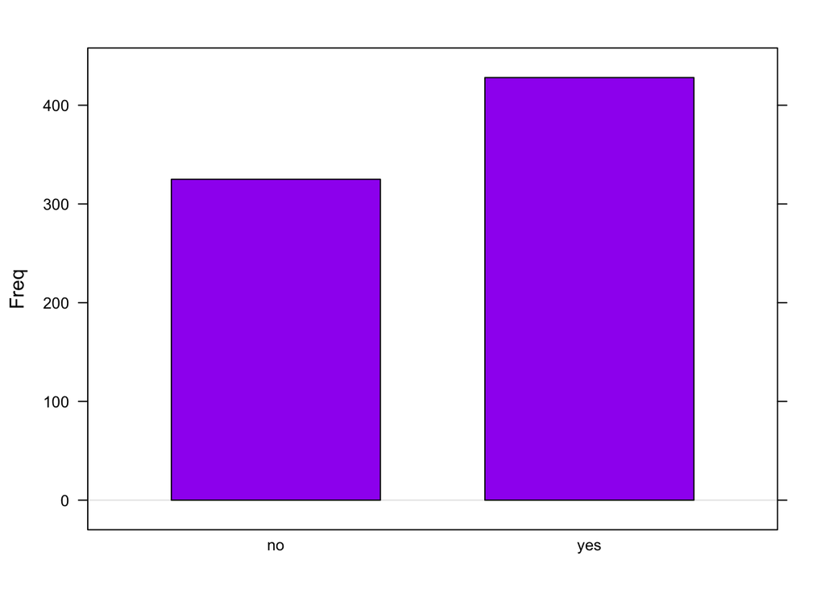

```r
barchart(table(Mroz$lfp), col="purple", horizontal = F)
```

### Stratified random split

Now, we will use the `createDataPartition` command from the `caret` package to perform a 70/30 stratified random split of the Mroz data into training and test sets.

```r
library(caret)
set.seed(1)
split <- createDataPartition(Mroz$lfp, p=0.70, list=FALSE)
training_set <- Mroz[split,]
test_set <- Mroz[-split,]

dim(Mroz)
```

```
## [1] 753   8
```

```r
dim(training_set)
```

```
## [1] 528   8
```

```r
dim(test_set)
```

```
## [1] 225   8
```

```r
nrow(training_set) + nrow(test_set) == nrow(Mroz) # double check
```

```
## [1] TRUE
```

##### 1.1 `rf1` - fit the model and evaluate `training_set` accuracy

Using the `randomForest` package, let`s fit a random forest model to predict the number of women who participated or did not participate in the labor force in 1975.

```r
library(randomForest)
?randomForest
set.seed(1)
rf1 <- randomForest(lfp ~ .,
                    data=training_set,
                    ntree=500,
                    mtry=round(sqrt(ncol(Mroz)), digits = 0),
                    importance=TRUE)
#NOTE: notice that our response vector `lfp` is a factor - this will assume classification models, otherwise regression will be assumed. If it is omitted entirely, randomForest becomes unsupervised!
rf1
```

```
##
## Call:
##  randomForest(formula = lfp ~ ., data = training_set, ntree = 500,      mtry = round(sqrt(ncol(Mroz)), digits = 0), importance = TRUE)
##                Type of random forest: classification
##                      Number of trees: 500
## No. of variables tried at each split: 3
##
##         OOB estimate of  error rate: 23.3%
## Confusion matrix:
##      no yes class.error
## no  170  58   0.2543860
## yes  65 235   0.2166667
```

```r
# check accuracy on training set
(170+235) / nrow(training_set)  # training_set = 77% accuracy
```

```
## [1] 0.7670455
```

```r
rf1$importance
```

```
##              no          yes MeanDecreaseAccuracy MeanDecreaseGini
## k5   0.04188139  0.005054751          0.020876020        13.482581
## k618 0.00743171  0.003697944          0.005217081        17.776937
## age  0.05263536  0.002326652          0.023849482        40.484267
## wc   0.03336732 -0.009137146          0.009259018         7.138699
## hc   0.02245096  0.003001667          0.011420889         7.368293
## lwg  0.17154817  0.088234810          0.123921727       109.983650
## inc  0.03064782  0.022007134          0.025697613        57.234729
```

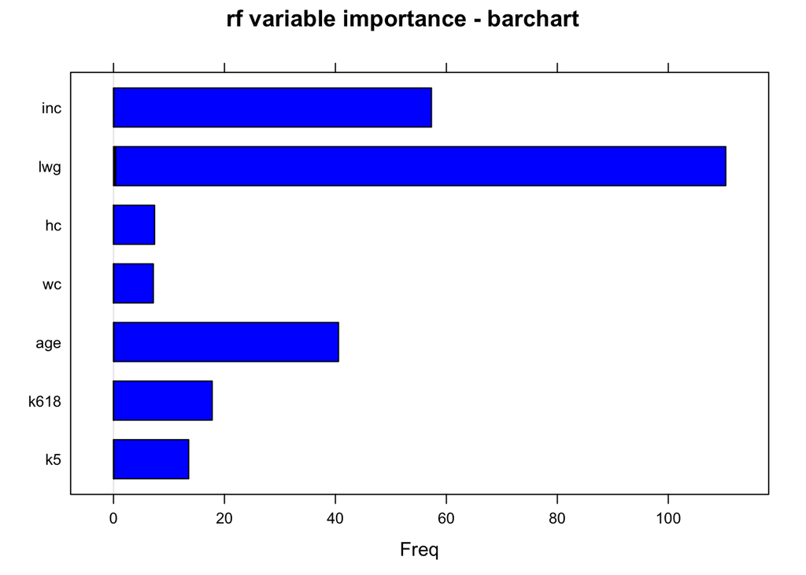

```r
barchart(rf1$importance, main="rf variable importance - barchart", col="blue", border="black")
```

##### 1.2 `randomForest` `test_set` accuracy

Now, let`s see how our model performs on the test data.

```r
set.seed(1)
pred <- predict(rf1, newdata=test_set)
table(pred, test_set$lfp)
```

```
##
## pred  no yes
##   no  68  29
##   yes 29  99
```

Of the 225 test_set observations, We have 68 true negatives (correct `no` predictions) and 99 true positives (correct `yes` predictions).

Now, we can quickly check the accuracy of the model using the holdout dataset.

```r
(68 + 99) / nrow(test_set)  #test_set = 74% accuracy
```

```
## [1] 0.7422222
```

##### 1.3 `plotmo` on `rf1`

Plot `rf1`!

```
##  plotmo grid:    k5 k618 age wc hc      lwg    inc
##                   0    1  43 no no 1.066783 17.935
```

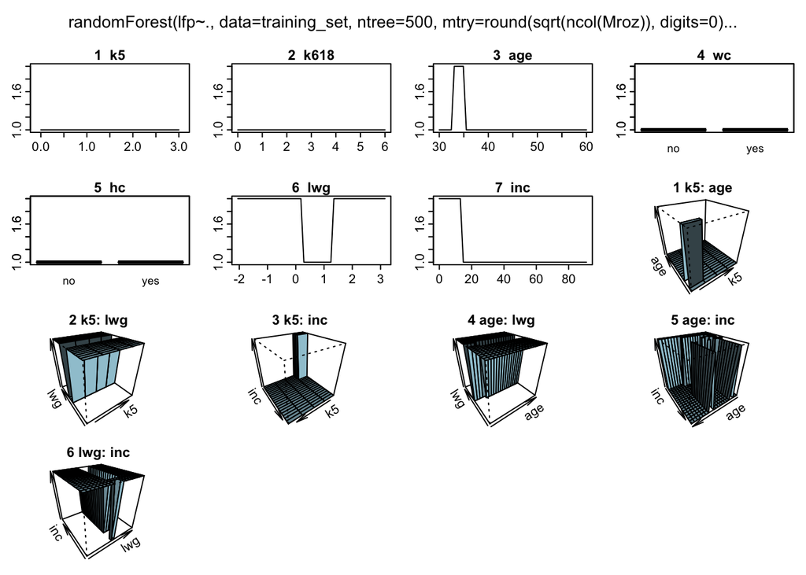

```r
library(plotmo)
?plotmo
plotmo(rf1, all1 = T) # all1 = T will plot all predictors
```

```
##  plotmo grid:    k5 k618 age wc hc      lwg    inc
##                   0    1  43 no no 1.066783 17.935
```

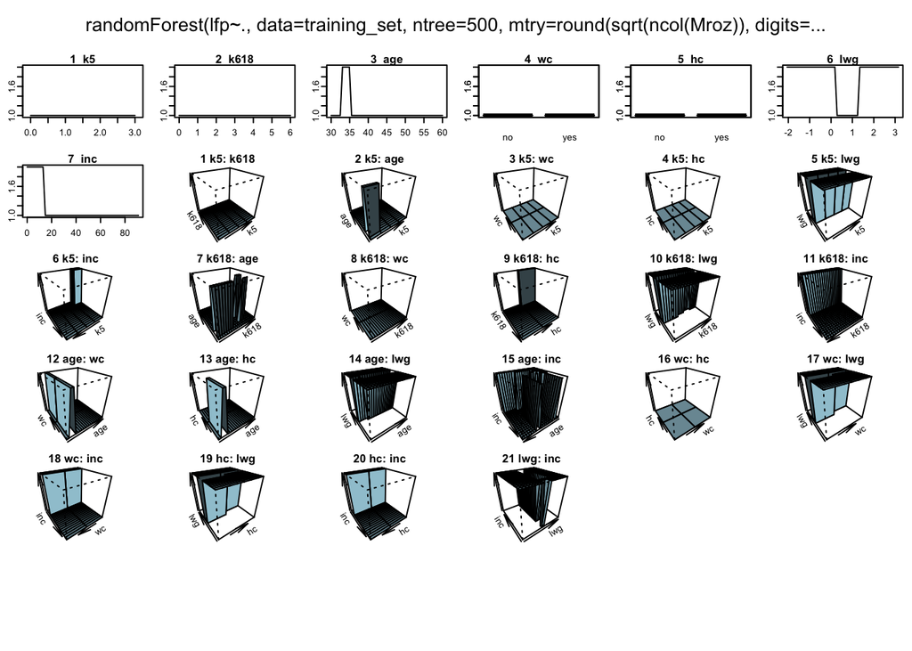

```r
plotmo(rf1, all2 = T) # all2 = T will plot all pairs of predictors
```

```
##  plotmo grid:    k5 k618 age wc hc      lwg    inc
##                   0    1  43 no no 1.066783 17.935
```

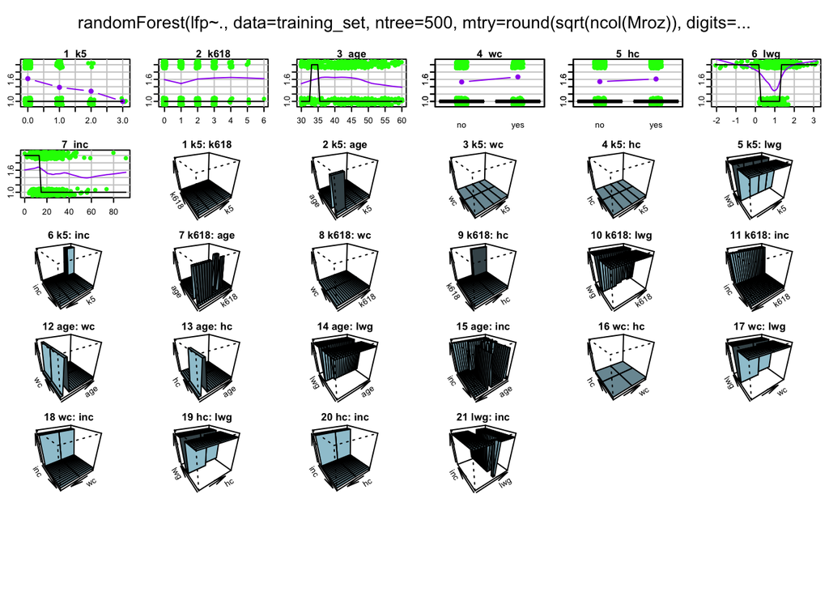

```r
plotmo(rf1, all2 = T, pt.col = "green", smooth.col = "purple", grid.col = "gray80")
```

```
## calculating apartdep for k5
## calculating apartdep for k618
## calculating apartdep for age
## calculating apartdep for wc
## calculating apartdep for hc
## calculating apartdep for lwg
## calculating apartdep for inc
## calculating apartdep for k5:age 0123456790
## calculating apartdep for k5:lwg 0123456790
## calculating apartdep for k5:inc 0123456790
## calculating apartdep for age:lwg 01234567890
## calculating apartdep for age:inc 01234567890
## calculating apartdep for lwg:inc 01234567890
```

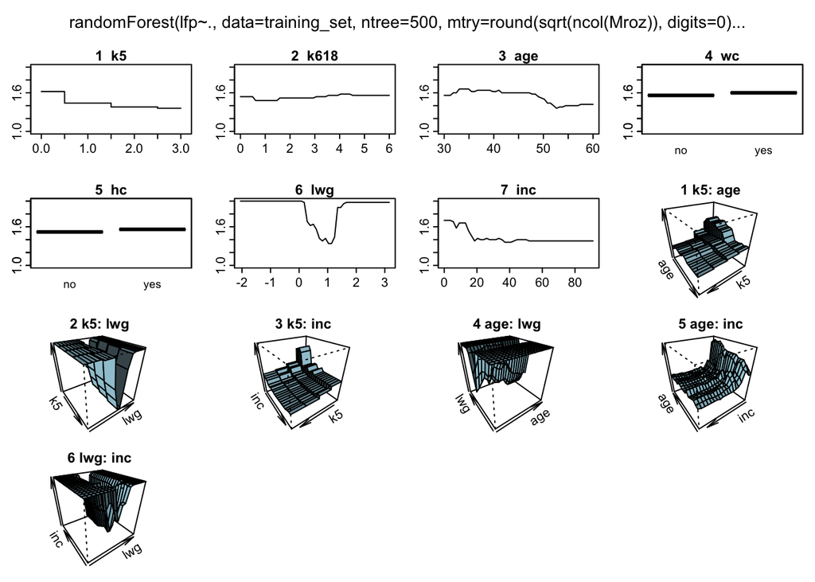

```r
set.seed(1)
plotmo(rf1, all1 = T, pmethod = "apartdep")
```

```
## calculating apartdep for k5:inc 0123456790
```

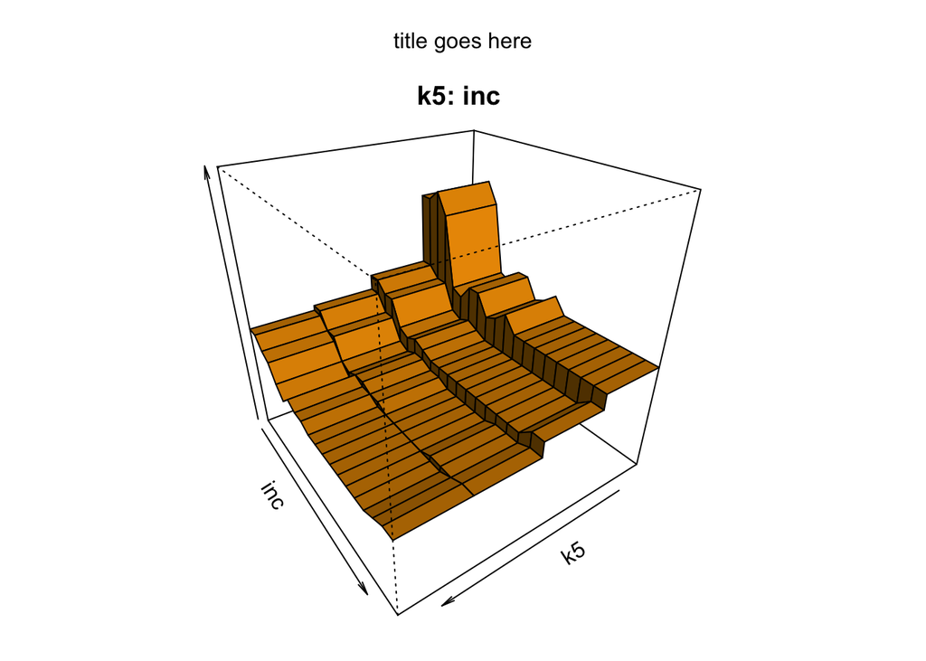

```r
set.seed(1)
plotmo(rf1, all1 = T, pmethod = "apartdep", degree1 = 0, degree2 = 3, # return just glucose v. pregnant perspective plot
       caption = "title goes here",
       persp.col="orange")
```

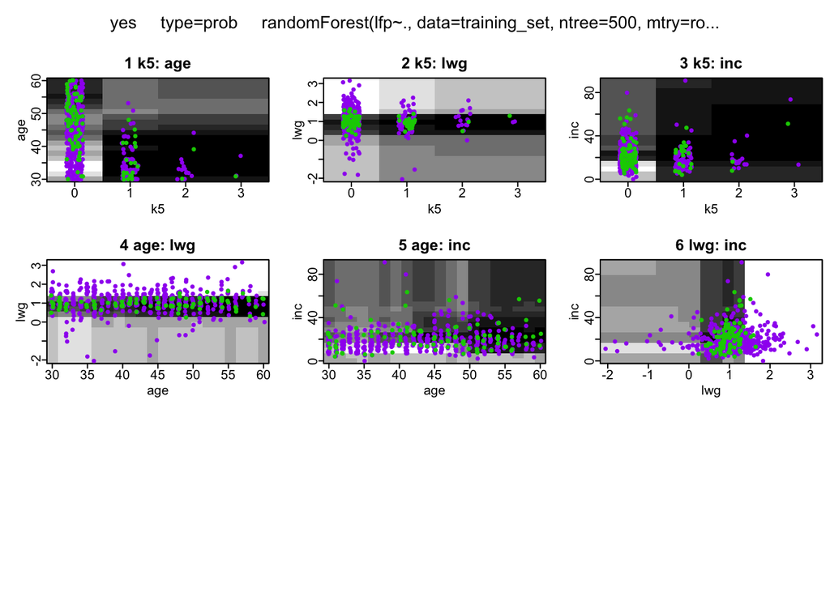

```r
# image plots
plotmo(rf1, degree1 = F, type="prob", nresponse="yes", # right graph
       type2="image", pt.col=ifelse(Mroz$lfp == "yes", "purple", "green3"))
```

# Compare multiple models using the `SuperLearner` R package

`SuperLearner` is an R package that allows you to easily compare multiple machine learning algorithms at once and/or the same algorithm with different settings.

It then creates an optimal weighted average of those models, aka an “ensemble”, using the test data performance. This approach has been proven to be asymptotically as accurate as the best possible prediction algorithm that is tested.

### Coerce `lfp` to integer type

For binary classification, SuperLearner prefers that your categorical outcome is numeric/integer, rather than factor data type.

Let’s coerce `lfp` from factor to integer type, but first make a copy of `training_set` and `test_set`.

```r
training_set2 = training_set
test_set2 = test_set

class(training_set2$lfp)
```

```
## [1] "factor"
```

```r
class(test_set2$lfp)
```

```
## [1] "factor"
```

```r
?ifelse
training_set2$lfp <- ifelse(training_set2$lfp=="yes", 1L, 0L)
test_set2$lfp <- ifelse(test_set2$lfp=="yes", 1L, 0L)

class(training_set2$lfp)
```

```
## [1] "integer"
```

```r
class(test_set2$lfp)
```

```
## [1] "integer"
```

```r
training_set2$lfp
test_set2$lfp
```

### Assign Y variables

Now, we should assign binary outcome variables for the training and test sets for the `SuperLearner` computations.

```r
Y <- training_set2$lfp
Y_test <- test_set2$lfp
table(Y)
```

```
## Y
##   0   1
## 228 300
```

```r
table(Y_test)
```

```
## Y_test
##   0   1
##  97 128
```

However, because we specify our outcome and predictor variables in SuperLearner, we must remove the outcome variable from our training and test sets because we do not want to include them as a predictor:

```r
training_set2 <- training_set2[,c(2:8)]
test_set2 <- test_set2[,c(2:8)]
dim(training_set2)
```

```
## [1] 528   7
```

```r
dim(test_set2)
```

```
## [1] 225   7
```

##### 2.1 `rf2` fit the second random forest model inside SuperLearner

```r
library(SuperLearner)
listWrappers() # we want "SL.randomForest"
```

```
## All prediction algorithm wrappers in SuperLearner:
```

```
##  [1] "SL.bartMachine"      "SL.bayesglm"         "SL.biglasso"
##  [4] "SL.caret"            "SL.caret.rpart"      "SL.cforest"
##  [7] "SL.dbarts"           "SL.earth"            "SL.extraTrees"
## [10] "SL.gam"              "SL.gbm"              "SL.glm"
## [13] "SL.glm.interaction"  "SL.glmnet"           "SL.ipredbagg"
## [16] "SL.kernelKnn"        "SL.knn"              "SL.ksvm"
## [19] "SL.lda"              "SL.leekasso"         "SL.lm"
## [22] "SL.loess"            "SL.logreg"           "SL.mean"
## [25] "SL.nnet"             "SL.nnls"             "SL.polymars"
## [28] "SL.qda"              "SL.randomForest"     "SL.ranger"
## [31] "SL.ridge"            "SL.rpart"            "SL.rpartPrune"
## [34] "SL.speedglm"         "SL.speedlm"          "SL.step"
## [37] "SL.step.forward"     "SL.step.interaction" "SL.stepAIC"
## [40] "SL.svm"              "SL.template"         "SL.xgboost"
```

```
##
## All screening algorithm wrappers in SuperLearner:
```

```
## [1] "All"
## [1] "screen.corP"           "screen.corRank"        "screen.glmnet"
## [4] "screen.randomForest"   "screen.SIS"            "screen.template"
## [7] "screen.ttest"          "write.screen.template"
```

```r
rf2 <- SuperLearner(Y = Y, X = training_set2, family = binomial(), SL.library = "SL.randomForest")

rf2
```

```
##
## Call:
## SuperLearner(Y = Y, X = training_set2, family = binomial(), SL.library = "SL.randomForest")
##
##
##
##                          Risk Coef
## SL.randomForest_All 0.1659946    1
```

In the output, Risk is an estimate of model accuracy/performance as estimated by cross-validation of risk on future data. By default it uses 10 folds.

Coef is how much weight SuperLearner puts on that model in the ensemble weighted-average. If Coef = 0 it means that model is not used at all.

# Compare multiple models simultaneously

Now, let’s compare our random forest model to two other tree-based models: `SL.rpart` and `SL.xgboost`.

We also include the mean of Y (`SL.mean`) as a benchmark algorithm - if it is the discrete winner, then we can assume that our model fits the data poorly.

Based on model performance (risk), SuperLearner will also tell us which model is the best (Discrete winner) and also create a weighted average of the multiple models (SuperLearnerer).

##### 3.1 `rf3` fit the SuperLearner randomForest model in an ensemble

```r
rf3 <- SuperLearner(Y = Y, X = training_set2, family = binomial(), SL.library = c("SL.mean", "SL.rpart", "SL.randomForest", "SL.xgboost"))
rf3
```

```
##
## Call:
## SuperLearner(Y = Y, X = training_set2, family = binomial(), SL.library = c("SL.mean",
##     "SL.rpart", "SL.randomForest", "SL.xgboost"))
##
##
##                          Risk      Coef
## SL.mean_All         0.2462550 0.0000000
## SL.rpart_All        0.1938440 0.1362802
## SL.randomForest_All 0.1702346 0.7330421
## SL.xgboost_All      0.1907785 0.1306777
```

##### 3.2 Assess model performance on `test_set2`

Then, we want to assess the model performance on test_set and illustrate with a simple barplot.

```r
pred2 <- predict(rf3, test_set2, onlySL = T)

summary(pred2$library.predict)
```

```
##        V1          V2               V3               V4
##  Min.   :0   Min.   :0.2000   Min.   :0.1000   Min.   :0.01365
##  1st Qu.:0   1st Qu.:0.2658   1st Qu.:0.3660   1st Qu.:0.25865
##  Median :0   Median :0.7500   Median :0.5910   Median :0.71804
##  Mean   :0   Mean   :0.6102   Mean   :0.5856   Mean   :0.60261
##  3rd Qu.:0   3rd Qu.:0.8919   3rd Qu.:0.8170   3rd Qu.:0.91389
##  Max.   :0   Max.   :1.0000   Max.   :0.9990   Max.   :0.99957
```

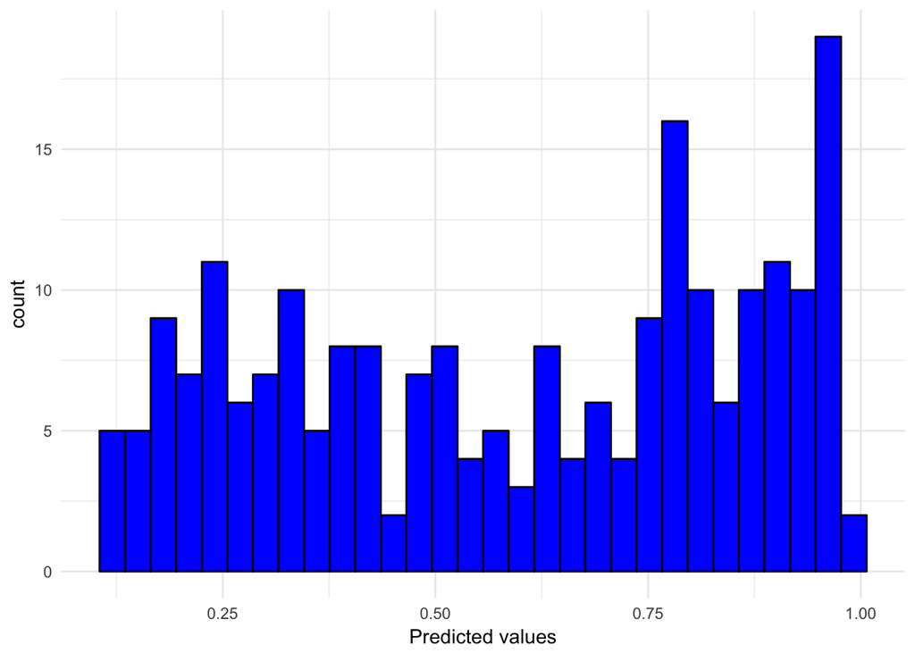

```r
ggplot(as.data.frame(pred2), aes(x = pred)) +
  geom_histogram(fill = "blue", color = "black") +
  xlab("Predicted values") +
  theme_minimal()
```

##### 3.3 AUC on `test_set2`

We can then check the area under the receiver operator characteristic (ROC) curve to see an alternative performance metric of `rf3` on `test_set2`:

```r
library(ROCR)
pred_rocr <- prediction(pred2$pred, Y_test)
auc <- performance(pred_rocr, measure = "auc", x.measure = "cutoff")@y.values[[1]]
auc     # AUC = 0.82
```

```
## [1] 0.8175741
```

##### 4.1 `rf4` fit the SuperLearner randomForest model in an ensemble with external cross-validation

Default cross-validation is set to 10-fold in SuperLearner. However, we can use (external) cross-validation via the `CV.SuperLearner` function. We can also use all the data since we are using this external layer of cross-validation.

```r
SL_Y = ifelse(Mroz$lfp == "yes", 1, 0)
SL_X = Mroz[,-1]

set.seed(1)

rf4 <- CV.SuperLearner(Y = SL_Y, X = SL_X, family = binomial(), V = 10, SL.library = c("SL.mean", "SL.rpart", "SL.randomForest", "SL.xgboost"))

rf4
```

```
##
## Call:
## CV.SuperLearner(Y = SL_Y, X = SL_X, V = 10, family = binomial(), SL.library = c("SL.mean",
##     "SL.rpart", "SL.randomForest", "SL.xgboost"))
##
##
## Cross-validated predictions from the SuperLearner:  SL.predict
##
## Cross-validated predictions from the discrete super learner (cross-validation selector):  discreteSL.predict
##
## Which library algorithm was the discrete super learner:  whichDiscreteSL
##
## Cross-validated prediction for all algorithms in the library:  library.predict
```

```r
names(rf4)
```

```
##  [1] "call"               "AllSL"              "SL.predict"
##  [4] "discreteSL.predict" "whichDiscreteSL"    "library.predict"
##  [7] "coef"               "folds"              "V"
## [10] "libraryNames"       "SL.library"         "method"
## [13] "Y"
```

```r
summary(rf4)
```

```
##
## Call:
## CV.SuperLearner(Y = SL_Y, X = SL_X, V = 10, family = binomial(), SL.library = c("SL.mean",
##     "SL.rpart", "SL.randomForest", "SL.xgboost"))
##
## Risk is based on: Mean Squared Error
##
## All risk estimates are based on V =  10
##
##            Algorithm     Ave        se     Min     Max
##        Super Learner 0.16453 0.0070643 0.13607 0.19696
##          Discrete SL 0.16427 0.0070095 0.13664 0.19586
##          SL.mean_All 0.24589 0.0024834 0.23965 0.26415
##         SL.rpart_All 0.19008 0.0089813 0.17191 0.21428
##  SL.randomForest_All 0.16427 0.0070095 0.13664 0.19586
##       SL.xgboost_All 0.18475 0.0095578 0.13968 0.23550
```

```r
table(simplify2array(rf4$whichDiscreteSL))
```

```
##
## SL.randomForest_All
##                  10
```

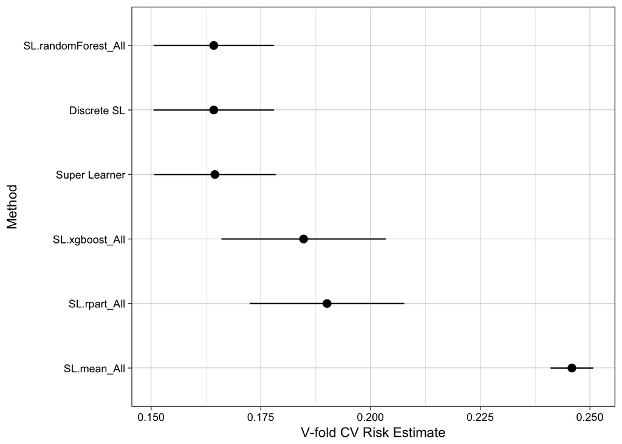

```r
plot(rf4) + theme_linedraw()
```

See these guides for more:  
[SuperLearner Guide](https://github.com/ck37/superlearner-guide)

To learn more about plotting decision boundaries in R, check out the mlr package examples [Quick start](http://mlr-org.github.io/mlr-tutorial/release/html/) and [Visualizations of predictions](https://mlr-org.github.io/Visualisation-of-predictions/)

[James G, Witten D, Hastie T, Tibshirani R. 2013. An Introduction to Statistical Learning - with Applications in R. New York: Springer](http://www-bcf.usc.edu/~gareth/ISL/ISLR%20First%20Printing.pdf)

[Package “SuperLearner”](https://cran.r-project.org/web/packages/SuperLearner/SuperLearner.pdf)